# R Notebook

```r
library(CodeClanData)
library(tidyverse)
```

*Question 1. Pre-analysis.*

```r
backpack
```

| backpack_weight | body_weight | ratio | back_problems | major | year | sex | status | units |
| --- | --- | --- | --- | --- | --- | --- | --- | --- |
| 9 | 125 | 0.0720000 | 1 | Bio | 3 | Female | U | 13 |
| 8 | 195 | 0.0410256 | 0 | Philosophy | 5 | Male | U | 12 |
| 10 | 120 | 0.0833333 | 1 | GRC | 4 | Female | U | 14 |
| 6 | 155 | 0.0387097 | 0 | CSC | 6 | Male | G | 0 |
| 8 | 180 | 0.0444444 | 0 | EE | 2 | Female | U | 14 |
| 5 | 240 | 0.0208333 | 0 | History | 0 | Male | G | 0 |
| 8 | 170 | 0.0470588 | 0 | CM | 3 | Male | U | 15 |
| 4 | 185 | 0.0216216 | 1 | ARCE | 5 | Female | U | 18 |
| 5 | 130 | 0.0384615 | 0 | Bio | 4 | Female | U | 14 |
| 2 | 120 | 0.0166667 | 0 | Bio | 5 | Female | U | 8 |

[output cut: 90 more lines]

The dimension of the considered dataset is 100 (observations) x 9 (variables) and is found by using the command:

```r
  dim(backpack)
```

```
[1] 100   9
```

The **backpack** dataset includes the following variables (or columns):

```r
names(backpack)
```

```
[1] "backpack_weight" "body_weight"     "ratio"           "back_problems"   "major"           "year"
[7] "sex"             "status"          "units"
```

Finally, the variables (columns) from the **backpack** dataset and their classification are shown in the table below:

| Integer | Double | Character |
| --- | --- | --- |
| backpack_weight | ratio | major |
| body_weight |  | sex |
| back_problems |  | status |
| year |  |  |
| units |  |  |

*Question 2. What is the distribution of backpack weights that students are carrying? Choose an appropriate graph to show the distribution.*

By using a bar-chart plot, a positive- skewed distribution is observed for the *backpack weights* variable.

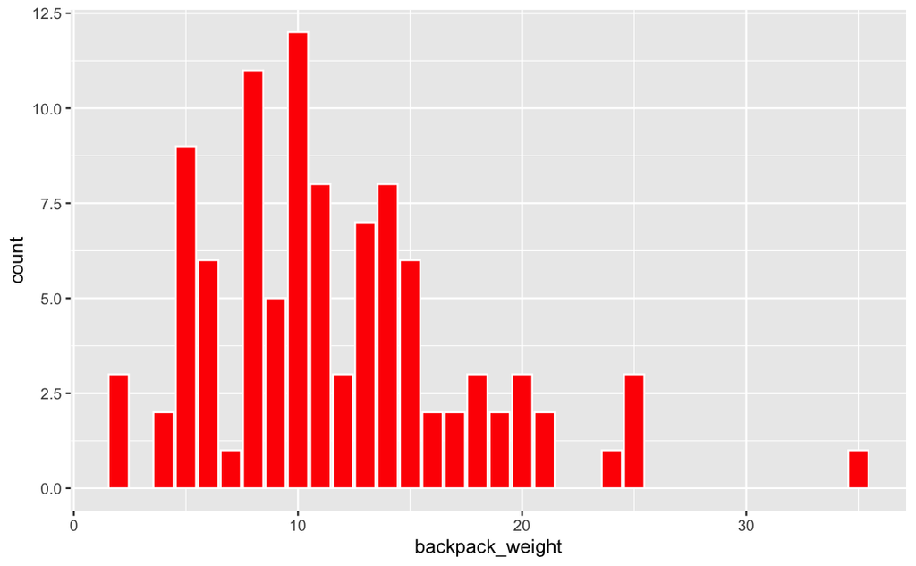

```r
ggplot(backpack) +
  geom_bar(aes(x = backpack_weight),col = "white", fill = "red")
```

*Question 3.Are there differences in backpack weight between sex?* In this example, the *postion = “dodge”* command is used in order to distinguish if there are any differences between male and female students in *backpack_weights*. As shown below, both males and females carry almsot the same weight of backpacks.

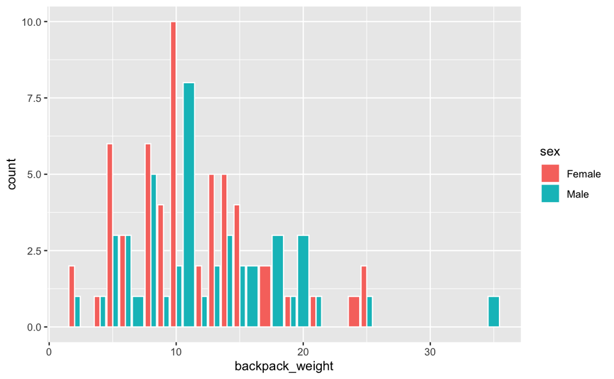

```r
ggplot(backpack) +
  geom_bar(aes(x = backpack_weight, fill = sex), col = "white", position = "dodge") +
  scale_colour_brewer()
```

We also use the the *postion = “fill”* command to see the differnce between the two genders. Once more, the graph shows that both genders havve almost same weight of backpacks.

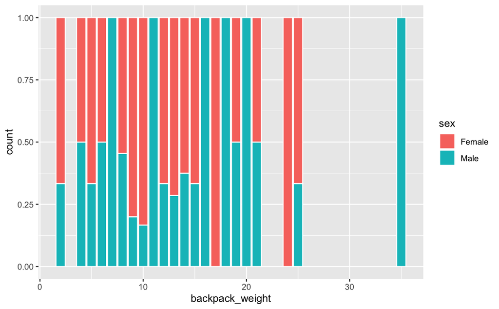

```r
ggplot(backpack) +
  geom_bar(aes(x = backpack_weight, fill = sex), col = "white", position = "fill") +
  scale_colour_brewer()
```

Finally, the command below is used to calculate the mean value of the backpack weight.

```r
backpack %>%
  select(backpack_weight, sex) %>%
  group_by(sex) %>%
  summarise(mean_backpack_weight= mean(backpack_weight))
```

| sex | mean_backpack_weight |
| --- | --- |
| Female | 11.03636 |
| Male | 12.42222 |

```r
NA
```

*Question 4.What is the relationship between body weight and backpack weight?*

In this example, we use a scatter plot to check if there is any correlation between students body_weight and their backpack_weight. As shown from the plot, there is no obvious relationship between the two variables since all the points are scatterd together.

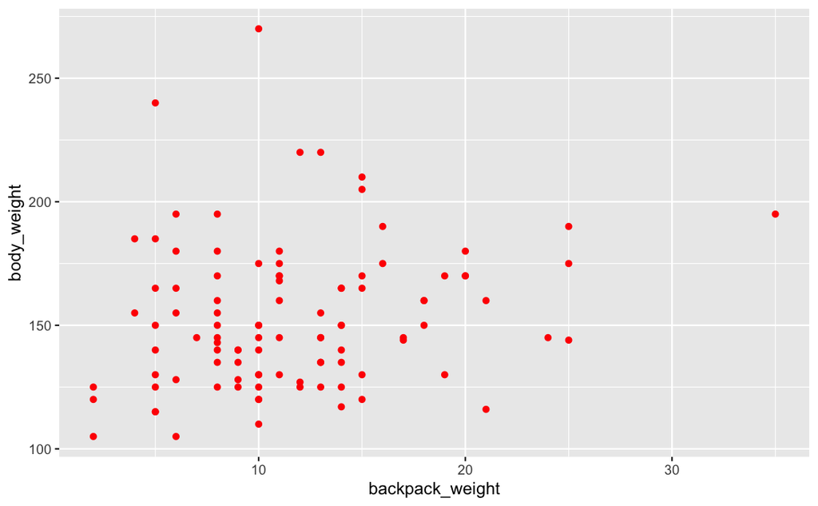

```r
ggplot(backpack) +
  geom_point(aes(x = backpack_weight, y = body_weight), colour = "red")
```

The command below also shows that the *backpack weight*i varies randomly by increasing the *body weight* and therefore we can conclude that both variables have not any relationship.

```r
backpack %>%
  select(body_weight, backpack_weight, ratio, sex) %>%
  arrange(body_weight)
```

| body_weight | backpack_weight | ratio | sex |
| --- | --- | --- | --- |
| 105 | 6 | 0.0571429 | Female |
| 105 | 2 | 0.0190476 | Female |
| 110 | 10 | 0.0909091 | Female |
| 115 | 5 | 0.0434783 | Female |
| 115 | 5 | 0.0434783 | Female |
| 116 | 21 | 0.1810340 | Female |
| 117 | 14 | 0.1196580 | Female |
| 120 | 10 | 0.0833333 | Female |
| 120 | 2 | 0.0166667 | Female |
| 120 | 15 | 0.1250000 | Female |

[output cut: 90 more lines]

*Question 5.Is this relationship different between men and women? Choose an appropriate plot and interpret your findings.?*

The above plot is revisited but this time the data points are associated with the *sex* variable. It is now clear to see that males have higher *body weight* in comparison to females. However, there is still no any difference between the bothe gender in regards to the *backpack weight*.

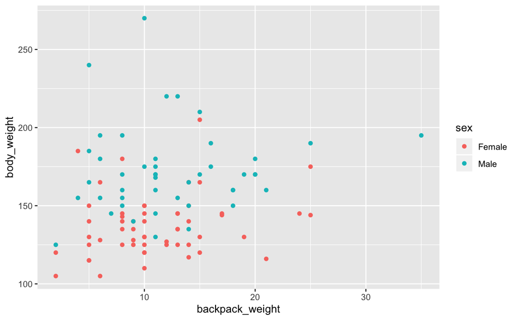

```r
ggplot(backpack) +
  geom_point(
    aes(x = backpack_weight, y = body_weight, colour = sex))
```

*Question 6.What proportion of students report back pain?*

Student that report back pain are denoted by the value of 1 whereas students without pain have value 0. The bar plot below shows that around 32-33% of students reported a back pain.

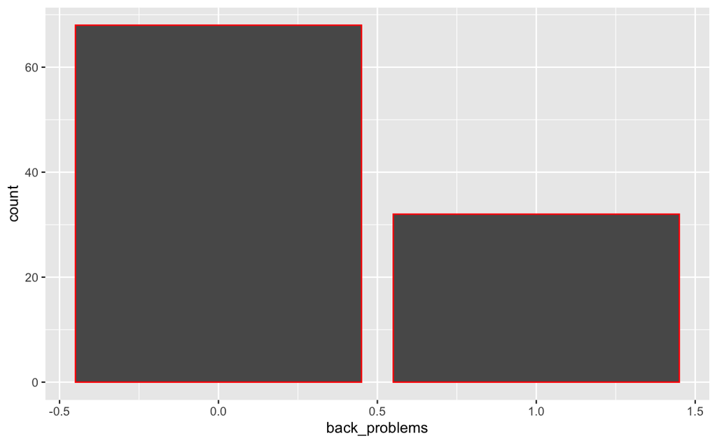

```r
ggplot(backpack) +
  geom_bar(aes(x = back_problems), colour = "red") +
  scale_colour_brewer()
```

*Question 7.Is this proportion different between men and women?*

The 25% of those students who report a back pain are males whereas the other 75% with a back pain are females. The plot below satisfies the results.

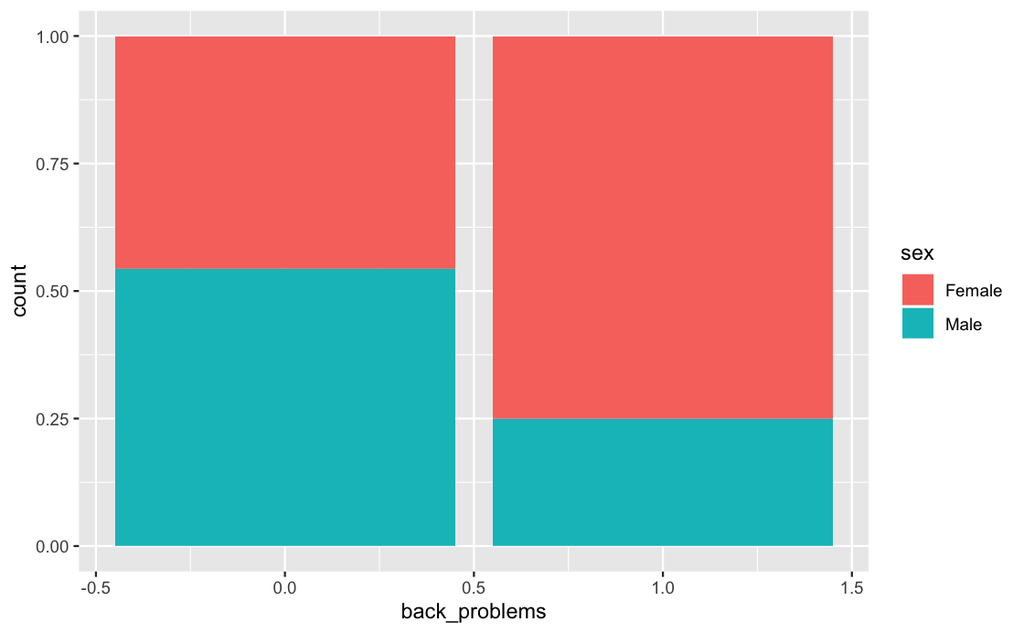

```r
ggplot(backpack) +
  geom_bar(aes(x = back_problems, fill = sex), position = "fill") +
  scale_colour_brewer()
```

*Question 8.2:Now you’ve investigated your data separately, create plots to describe the relationship between backpack weight, body weight, gender and reported backpain.*